# Reproducible Research: Peer Assessment 1

## Loading and preprocessing the data

```r
    require(plyr)
```

```r
    require(ggplot2)
    x <- read.csv("data/activity.csv")
    x$date <- strptime(x$date, "%Y-%m-%d")
    #x <- subset(x, select=c(steps, interval, pDate))
```

## What is mean & median total number of steps taken per day?

1. Calculate the total number of steps taken per day:

```r
tspd <- ddply(x, .(date), summarise, t.steps.day=sum(steps, na.rm=TRUE))
tspd
```

```
##          date t.steps.day
## 1  2012-10-01           0
## 2  2012-10-02         126
## 3  2012-10-03       11352
## 4  2012-10-04       12116
## 5  2012-10-05       13294
## 6  2012-10-06       15420
## 7  2012-10-07       11015
## 8  2012-10-08           0
## 9  2012-10-09       12811
## 10 2012-10-10        9900
## 11 2012-10-11       10304
## 12 2012-10-12       17382
## 13 2012-10-13       12426
## 14 2012-10-14       15098
```

[output cut: 47 more lines]

2. Histogram of the total number of steps taken per day:

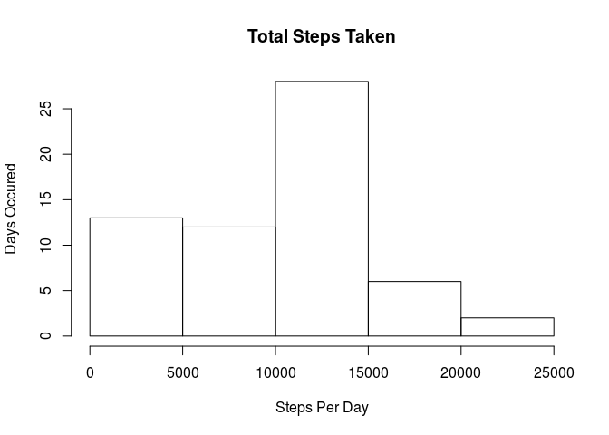

```r
hist(tspd$t.steps.day, xlab="Steps Per Day",
     ylab="Days Occured", main="Total Steps Taken")
```

3. Mean & Median Calculation: *Note that NA values were removed. More on the missing values later.*

```r
mymean <- round(mean(tspd$t.steps.day, na.rm=TRUE), digits=2)
mymedian <- round(median(tspd$t.steps.day, na.rm=TRUE), digits=2)
```

- **Mean**: 9354.23
- **Median**: 1.0395 × 10<sup>4</sup>

## What is the average daily activity pattern?

1. Time series plot of the 5-minute interval (x-axis) and the average number of steps taken, averaged across all days (y-axis)

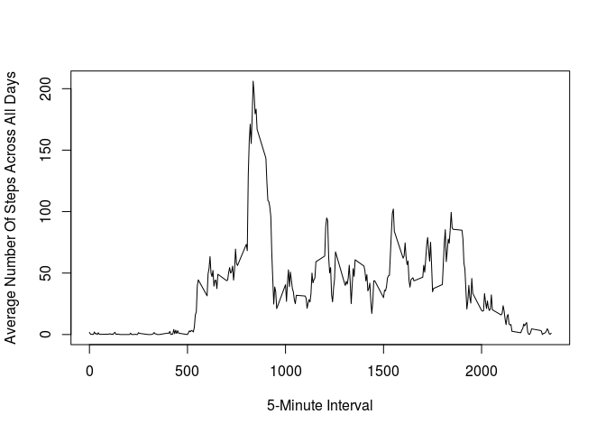

```r
int <- ddply(x, .(interval), summarise, mean_interval=mean(steps, na.rm=TRUE))
plot(int$interval, int$mean_interval, type="l", xlab="5-Minute Interval", ylab="Average Number Of Steps Across All Days" )
```

2. Which 5-minute interval, on average across all the days in the dataset, contains the maximum number of steps?

```r
maxsteps <- max(int$mean_interval)
DFmaxinterval <- subset(int, mean_interval==maxsteps, select=c(interval, mean_interval))
maxinterval <- DFmaxinterval[,1]
```

The interval 835 contains the maxium number of steps on average across all days.

## Imputing missing values

1. Calculate and report the total number of missing values in the dataset (i.e. the total number of rows with NAs).

```r
bad <- is.na(x$steps)
missingvalues <- nrow(subset(x, bad))
```

- There are 2304 number of NAs in the dataset.
2. Devise a strategy for filling in all of the missing values in the dataset. Then create a new dataset that is equal to the original dataset but with the missing data filled in.

```r
xNAs <- x
for(i in 1:nrow(xNAs)){
    if(is.na(xNAs$steps[i])){
        xNAs$steps[i] <- int$mean_interval[which(xNAs$interval[i]==int$interval)]
    }
}
```

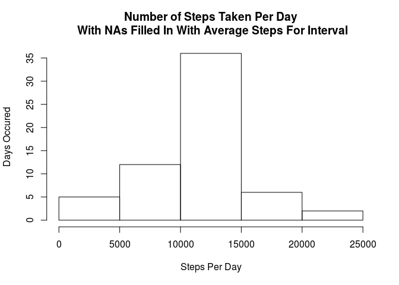

```r
tspd2 <- ddply(xNAs, .(date), summarise, t.steps.day=sum(steps, na.rm=TRUE))
hist(tspd2$t.steps.day, xlab="Steps Per Day", ylab="Days Occured", main="Number of Steps Taken Per Day\n With NAs Filled In With Average Steps For Interval")
```

```r
mymean2 <- round(mean(tspd2$t.steps.day, na.rm=TRUE), digits=2)
mymedian2 <- round(median(tspd2$t.steps.day, na.rm=TRUE), digits=2)
meanchange <- round(mymean-mymean2, digits=2)
medianchange <- round(mymedian - mymedian2, digits=2)
```

## Are there differences in activity patterns between weekdays and weekends?

For this part the weekdays() function may be of some help here. Use the dataset with the filled-in missing values for this part.

1. Create a new factor variable in the dataset with two levels – “weekday” and “weekend” indicating whether a given date is a weekday or weekend day.

```r
daf <- function(y){
    output <- vector()
    for(i in 1:length(y)){
        if(y[i] %in% c("Monday", "Tuesday", "Wednesday", "Thursday", "Friday")){
            output[i] <- "Weekday"
        }else if(y[i] %in% c("Saturday", "Sunday")){
            output[i] <- "Weekend"
        }
    }
    output
}
xNAs <- mutate(xNAs, day=weekdays(date))
dayofweek <- factor(daf(xNAs$day))
xNAs <- cbind(xNAs, dayofweek)
```

2. Make a panel plot containing a time series plot (i.e. type = “l”) of the 5-minute interval (x-axis) and the average number of steps taken, averaged across all weekday days or weekend days (y-axis). See the README file in the GitHub repository to see an example of what this plot should look like using simulated data.

**Average Number of Steps Across All Weekend and Weekdays**

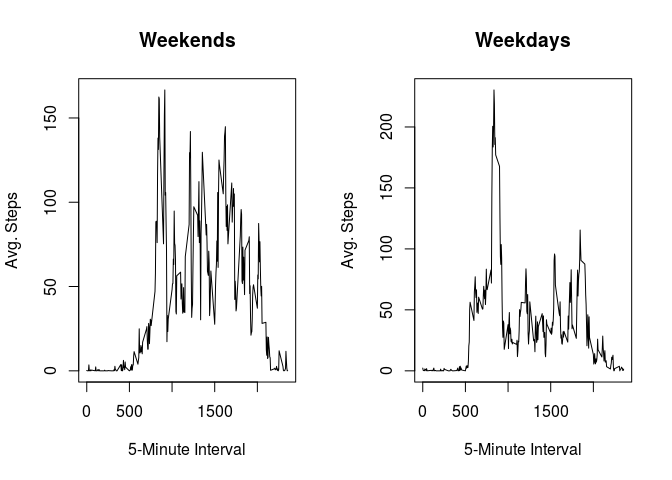

```r
xNAs.wend <- subset(xNAs, dayofweek=="Weekend")
xNAs.wday <- subset(xNAs, dayofweek=="Weekday")

wend <- ddply(xNAs.wend, .(interval), summarise, mean_interval=mean(steps, na.rm=TRUE))
wday <- ddply(xNAs.wday, .(interval), summarise, mean_interval=mean(steps, na.rm=TRUE))

par(mfrow=c(1,2))

plot(wend$interval, wend$mean_interval, type="l", xlab="5-Minute Interval", ylab="Avg. Steps", main="Weekends" )
plot(wday$interval, wday$mean_interval, type="l", xlab="5-Minute Interval", ylab="Avg. Steps", main="Weekdays" )
```